# Final_project_math156

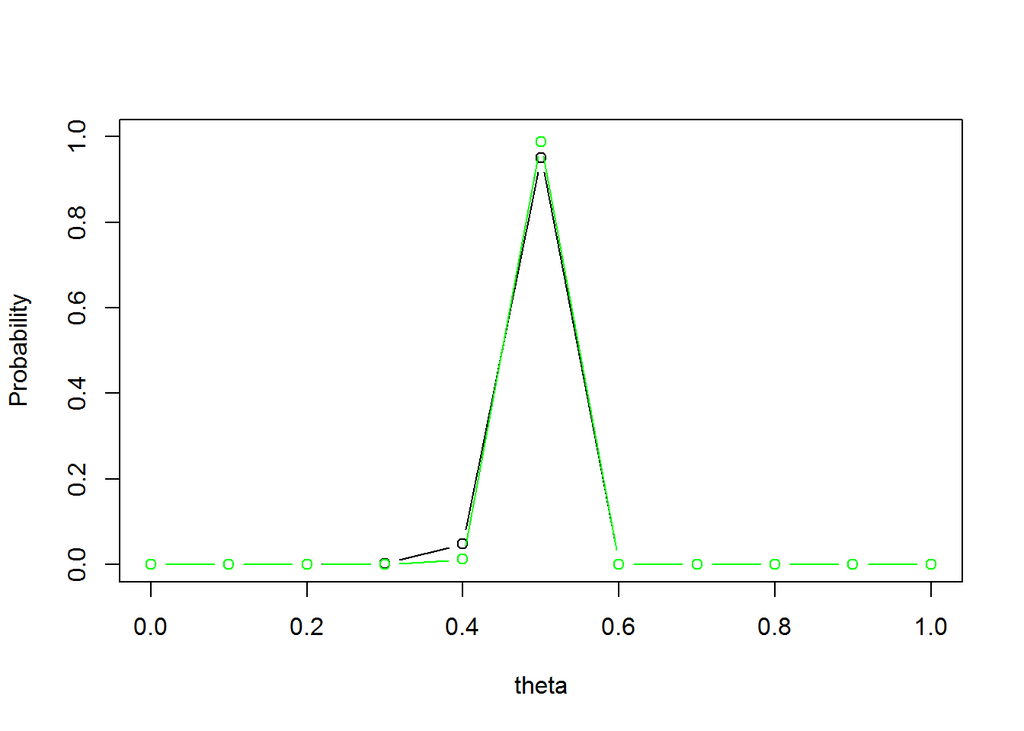

```r
plot(theta, posterior3, type = "b", ylim = c(0, 1), ylab = "Probability")
lines(theta, posterior4, type="b", col = "green")
```

(b) Comparison of analysis by Bayesian and frequentist approaches Appropriate use of bootstrap techniques

Jobs by designated education level of occupations, May 2013 reference(http://www.bls.gov/careeroutlook/2014/article/education-level-and-jobs.htm) 46 of the 200 people who have bachelor degree or above

bootstrap confidence interval

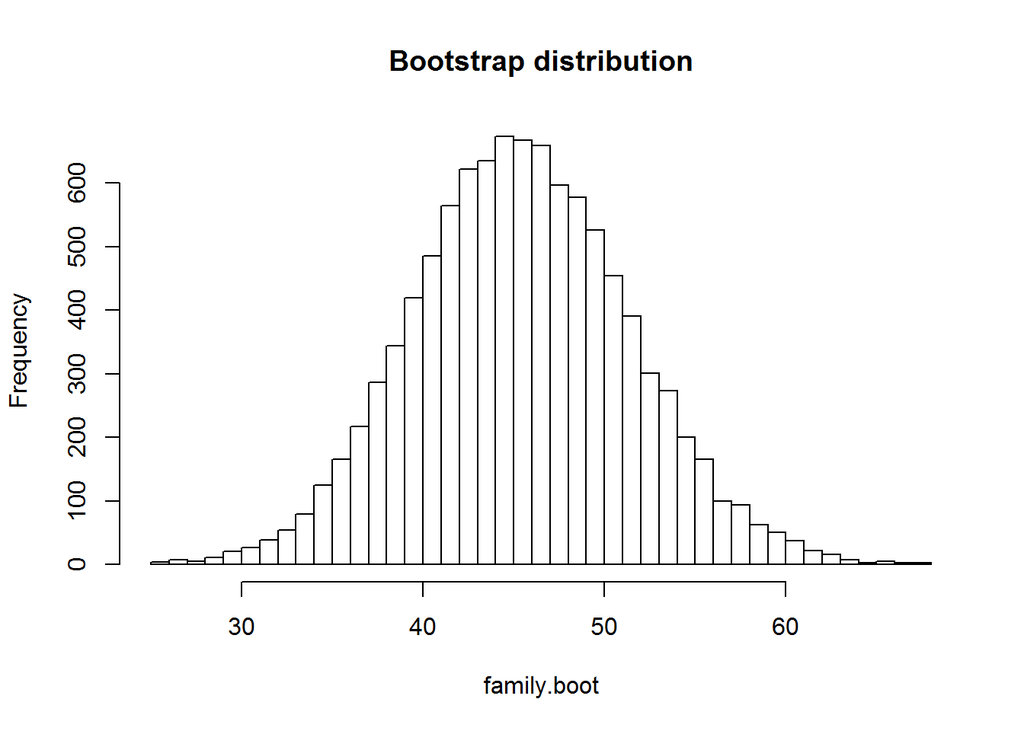

```r
graduate <-c(rep(0,154),rep(1,46))
N<-10^4; family.boot <- numeric(N)
for (i in 1:N) {
  fam.sample <- sample(graduate, replace = TRUE)
  family.boot[i] <- sum(fam.sample)
}
hist(family.boot, breaks = "FD", main= "Bootstrap distribution")
```

```r
#Extract a 95% bootstrap percentile confidence interval - proportion who responded yes
quantile(family.boot, c(.025, .975))/178
```

```
##      2.5%     97.5%
## 0.1966292 0.3258427
```

```r
# 2.5%     97.5%
#   0.1966292 0.3258427
```

4. Multiple linear regression

DATE: Time period (1-30) CONSUME: Ice cream consumption in pints per capita PRICE: Per pint price of ice cream in dollars INC: Weekly family income in dollars TEMP: Mean temperature in degrees F

I investigate the factors affecting Ice cream consumption Also, is there any interactions among those factors

```r
iceCreamConsumption <- read.table("C:/Users/peimo/Desktop/MATH 156/Final_Project/Data/iceCreamConsumption.csv", header=TRUE, quote="\"")
```

remove null missing value

```r
iceCreamConsumption<-subset(iceCreamConsumption,subset=Lag.temp!='?')
```

```r
m_ic<-lm(IC~price + temp+income, data=iceCreamConsumption)
summary(m_ic)
```

```
##
## Call:
## lm(formula = IC ~ price + temp + income, data = iceCreamConsumption)
##
## Residuals:
##       Min        1Q    Median        3Q       Max
## -0.059405 -0.015665  0.005229  0.017157  0.070515
##
## Coefficients:
##               Estimate Std. Error t value Pr(>|t|)
## (Intercept)  0.0877445  0.2447400   0.359   0.7230
## price       -0.3863577  0.7830856  -0.493   0.6261
## temp         0.0031191  0.0004168   7.483 7.78e-08 ***
## income       0.0026176  0.0010765   2.432   0.0225 *
## ---
## Signif. codes:  0 '***' 0.001 '**' 0.01 '*' 0.05 '.' 0.1 ' ' 1
##
## Residual standard error: 0.03291 on 25 degrees of freedom
## Multiple R-squared:  0.6948, Adjusted R-squared:  0.6582
## F-statistic: 18.97 on 3 and 25 DF,  p-value: 1.256e-06
```

R-squared: 0.6948, Adjusted R-squared: 0.6582 with relative high r-squared and Adjusted R-squared, the model looks good!

```r
par(mfrow = c(2, 2))
plot(hb_m.lm)
```

[output not shown]

```r
par(mfrow = c(1, 1))
```

detect if there is interaction tearm I suspect price and income interactoin term

```r
m_ic<-lm(IC~price + temp+income+price*income, data=iceCreamConsumption)
summary(m_ic)
```

```
##
## Call:
## lm(formula = IC ~ price + temp + income + price * income, data = iceCreamConsumption)
##
## Residuals:
##       Min        1Q    Median        3Q       Max
## -0.057528 -0.016359 -0.000848  0.016866  0.071892
##
## Coefficients:
##                Estimate Std. Error t value Pr(>|t|)
## (Intercept)  -6.3298130  3.1053503  -2.038   0.0527 .
## price        23.3540200 11.4796351   2.034   0.0531 .
## temp          0.0028231  0.0004171   6.769 5.31e-07 ***
## income        0.0780758  0.0364267   2.143   0.0424 *
## price:income -0.2786003  0.1344397  -2.072   0.0491 *
## ---
## Signif. codes:  0 '***' 0.001 '**' 0.01 '*' 0.05 '.' 0.1 ' ' 1
##
## Residual standard error: 0.03094 on 24 degrees of freedom
## Multiple R-squared:  0.7411, Adjusted R-squared:  0.698
## F-statistic: 17.18 on 4 and 24 DF,  p-value: 8.968e-07
```

I can see ineractin term price:income is signficant with p value of 0.0491.  
I can see that after adding interaction term the r squre increases also adjusted r squre increases before adding interaction term R-squared: 0.6948, Adjusted R-squared: 0.6582 after adding interaction term R-squared: 0.7411, Adjusted R-squared: 0.698

overall model: Multiple R-squared: 0.7411, Adjusted R-squared: 0.698 F-statistic: 17.18 on 4 and 24 DF, p-value: 8.968e-07 the model is significant

t= 6.769 and p value is 5.31e-07 and so we reject null hypothesis. There is relationship between CreamConsum and temperature. After accounting for other fators.

t= 2.143 and p value is 0.0424 and so we reject null hypothesis. There is relationship between CreamConsum and income After accounting for other fators.

t= -2.072 and p value is 0.0491 and so we reject null hypothesis. There is relationship between CreamConsum and price:income After accounting for other fators.

```r
par(mfrow = c(2, 2))
plot(hb_m.lm)
```

[output not shown]

```r
par(mfrow = c(1, 1))
```

check Multicollinarity When some of your predictor variables are correlated

```r
vif(m_ic)
```

```
##        price         temp       income price:income
##    244.51895      1.33091   1526.23069   1714.78293
```

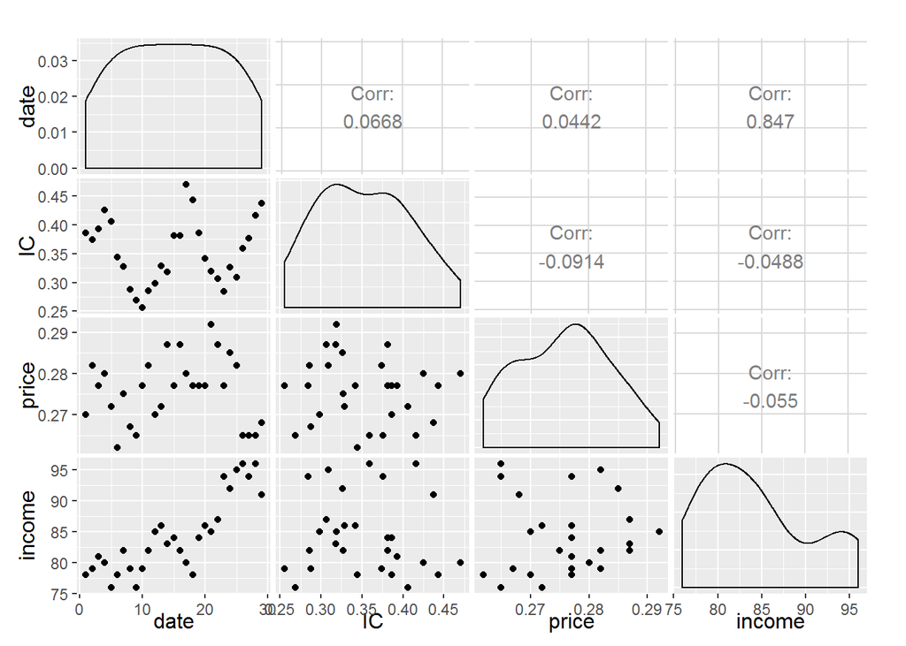

```r
ggpairs(iceCreamConsumption[,1:4])
```

```r
cor(iceCreamConsumption[,2:4])
```

```
##                 IC       price      income
## IC      1.00000000 -0.09138949 -0.04878008
## price  -0.09138949  1.00000000 -0.05501268
## income -0.04878008 -0.05501268  1.00000000
```

[figure not shown]

```r
pairs(iris[,1:4])
```

Prediction price=0.23,temp=50, income=50, price_income=50

```r
mass <- data.frame(price=0.23,temp=50, income=50, price_income=50)
confint_mass <- predict(m_ic, mass, interval=c("confidence"))
print(confint_mass)
```

```
##          fit        lwr      upr
## 1 -0.1173488 -0.5319696 0.297272
```

```r
predint_mass <- predict(m_ic, mass, interval=c("prediction"))
print(predint_mass)
```

```
##          fit       lwr       upr
## 1 -0.1173488 -0.536858 0.3021603
```

```r
par(mfrow = c(2, 2))
visreg(m_ic,main='confidence interval & prediction interval')
```

```
## Please note that you are attempting to plot a 'main effect' in a
## model that contains an interaction.  This is potentially
## misleading; you may wish to consider using the 'by' argument.
##
## Conditions used in construction of plot
## temp: 47
## income: 83
```

```
## Please note that you are attempting to plot a 'main effect' in a
## model that contains an interaction.  This is potentially
## misleading; you may wish to consider using the 'by' argument.
##
## Conditions used in construction of plot
## price: 0.277
## income: 83
```

```
## Please note that you are attempting to plot a 'main effect' in a
## model that contains an interaction.  This is potentially
## misleading; you may wish to consider using the 'by' argument.
##
## Conditions used in construction of plot
## price: 0.277
## temp: 47
```

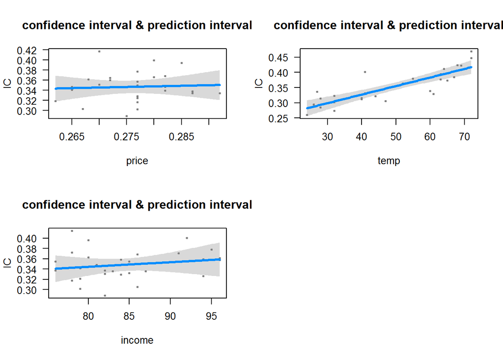

```r
par(mfrow = c(1, 1))
```

3. Logistic regression, SVM, KNN

About the data Household Income (Income; rounded to the nearest $1,000.00) Gender (IsFemale = 1 if the person is female, 0 otherwise) Marital Status (IsMarried = 1 if married, 0 otherwise) College Educated (HasCollege = 1 if has one or more years of college education, 0 otherwise) Employed in a Profession (IsProfessional = 1 if employed in a profession, 0 otherwise) Retired (IsRetired = 1 if retired, 0 otherwise) Not employed (Unemployed = 1 if not employed, 0 otherwise) Length of Residency in Current City (ResLength; in years) Dual Income if Married (Dual = 1 if dual income, 0 otherwise) Children (Minors = 1 if children under 18 are in the household, 0 otherwise) Home ownership (Own = 1 if own residence, 0 otherwise) Resident type (House = 1 if residence is a single family house, 0 otherwise) Race (White = 1 if race is white, 0 otherwise) Language (English = 1 is the primary language in the household is English, 0 otherwise)

the data is from a website. about customer’s information and if they buy from the site or not i want to use logistic regressino and other machine learning models to make a good classifier to help marketing team to target certain customers

our strategy is to send right customers’s emails and coupons the worst situation is they would respond us to buy our products but we thought they would not!

```r
KidCreative <- read.csv("C:/Users/peimo/Desktop/MATH 156/Final_Project/Data/KidCreative.csv")
KidCreative[,"Obs.No."]<- NULL
```

a receiver operating characteristic (ROC), or ROC curve, is a graphical plot that illustrates the performance of a binary classifier system as its discrimination threshold is varied. The curve is created by plotting the true positive rate (TPR) against the false positive rate (FPR) at various threshold settings. The true-positive rate is also known as sensitivity, or recall in machine learning.

```r
ROC_curve <- function(model,t_set,resp)
{
  prob <- predict(model, newdata=t_set, type="response")
  pred <- prediction(prob, resp)
  perf <- performance(pred, measure = "tpr", x.measure = "fpr")
  auc <- performance(pred, measure = "auc")
  auc <- auc@y.values[[1]]

  roc.data <- data.frame(fpr=unlist(perf@x.values),
                         tpr=unlist(perf@y.values),
                         model="GLM")

  ggplot(roc.data, aes(x=fpr, ymin=0, ymax=tpr)) +
    geom_ribbon(alpha=0.2) +
    geom_line(aes(y=tpr)) +
    ggtitle(paste0("ROC Curve w/ AUC=", auc))
}
```

```r
rmse <- function(error)
{
  sqrt(mean(error^2))
}
```

logistic regression

```r
cus_m<-glm(Buy~.,data=KidCreative,family=binomial)
summary(cus_m)
```

```
##
## Call:
## glm(formula = Buy ~ ., family = binomial, data = KidCreative)
##
## Deviance Residuals:
##      Min        1Q    Median        3Q       Max
## -2.36655  -0.08416  -0.00955  -0.00149   2.49038
##
## Coefficients:
##                    Estimate Std. Error z value Pr(>|z|)
## (Intercept)      -1.791e+01  2.223e+00  -8.058 7.74e-16 ***
## Income            2.016e-04  2.359e-05   8.545  < 2e-16 ***
## Is.Female         1.646e+00  4.651e-01   3.539 0.000401 ***
## Is.Married        5.662e-01  5.864e-01   0.966 0.334272
## Has.College      -2.794e-01  4.437e-01  -0.630 0.528962
## Is.Professional   2.253e-01  4.650e-01   0.485 0.627981
## Is.Retired       -1.159e+00  9.323e-01  -1.243 0.214015
## Unemployed        9.886e-01  4.690e+00   0.211 0.833030
## Residence.Length  2.468e-02  1.380e-02   1.788 0.073798 .
## Dual.Income       4.518e-01  5.215e-01   0.866 0.386279
## Minors            1.133e+00  4.635e-01   2.444 0.014521 *
## Own               1.056e+00  5.594e-01   1.888 0.058976 .
## House            -9.265e-01  6.218e-01  -1.490 0.136238
## White             1.864e+00  5.454e-01   3.417 0.000632 ***
## English           1.530e+00  8.407e-01   1.821 0.068678 .
## Prev.Child.Mag    1.557e+00  7.119e-01   2.188 0.028704 *
## Prev.Parent.Mag   4.777e-01  6.240e-01   0.766 0.443900
## ---
## Signif. codes:  0 '***' 0.001 '**' 0.01 '*' 0.05 '.' 0.1 ' ' 1
##
## (Dispersion parameter for binomial family taken to be 1)
##
##     Null deviance: 646.05  on 672  degrees of freedom
## Residual deviance: 182.33  on 656  degrees of freedom
## AIC: 216.33
##
## Number of Fisher Scoring iterations: 9
```

```r
error <- cus_m$residuals  # same as data$Y - predictedY
predictionRMSE <- rmse(error)   # 5.703778
predictionRMSE
```

```
## [1] 2.116948
```

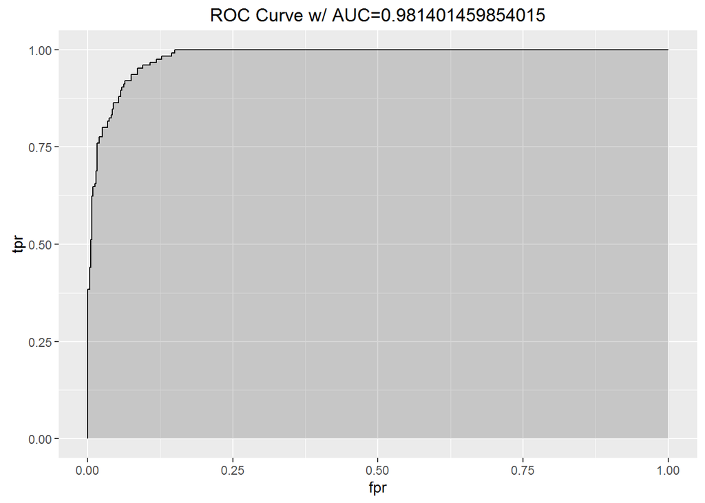

```r
ROC_curve(cus_m,KidCreative,KidCreative$Buy)
```

support vector machine

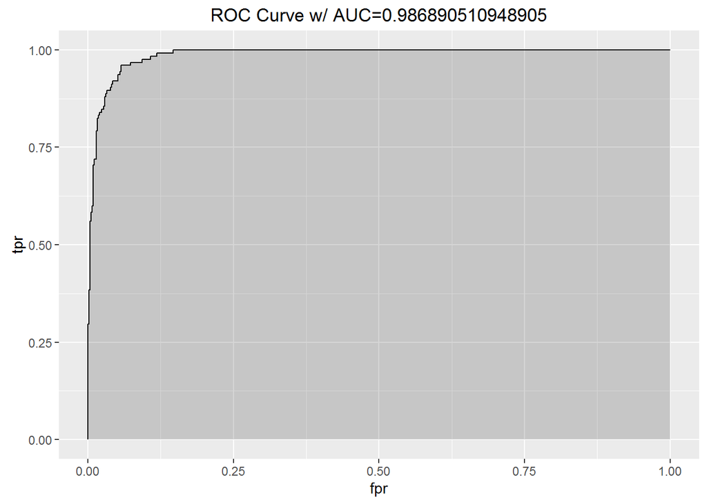

```r
cus_m<-svm(Buy~.,data=KidCreative,family=binomial)

ROC_curve(cus_m,KidCreative,KidCreative$Buy)
```

```r
error <- cus_m$residuals  # same as data$Y - predictedY
predictionRMSE <- rmse(error)   # 5.703778
predictionRMSE
```

```
## [1] 0.2060878
```

# 0.2060878